# Bricks, Markets and Rates

Firm development, market performance and macroeconomic exposure among Switzerland’s largest listed real-estate companies, with a property-level analysis of the three market leaders

Alix Potelleret & Julio Dinis

September 2026

# 1 Introduction and Data

## 1.1 Motivation

Swiss listed real-estate operating companies (REOCs) sit at the intersection of **public equity markets, corporate finance and physical real estate**. Their performance therefore reflects both firm-specific characteristics and broader conditions such as interest rates, inflation and economic activity.

At the same time, REOCs differ substantially in **size, leverage, profitability and portfolio composition**. Looking only at stock-market performance can therefore obscure important differences in the businesses and assets underlying those returns.

This report connects these perspectives. It first examines how Swiss listed REOCs have developed financially and in the stock market, then investigates their relationship with the macroeconomic environment.

Finally, the analysis moves from firms to buildings. The three largest companies are examined at property level, linking their financial and market characteristics to the **scale, geography, age and composition of their underlying real-estate portfolios**.

## 1.2 Research Questions

RQ1

FIRM DEVELOPMENT

How have the financial characteristics and market performance of Swiss listed real-estate companies developed over time?

RQ2

MARKET × MACRO

How is the stock-market performance of Swiss listed real-estate companies associated with changes in the macroeconomic environment?

RQ3

FUNDAMENTALS × MACRO

How are firm-level financial characteristics associated with changes in the macroeconomic environment?

The report then moves below the firm level, examining the property portfolios of the three companies that dominate the selected market by capitalization.

## 1.3 Data and Methodology

Five data layers connect **firms, markets, macroeconomic conditions and physical properties**. They are retained at their natural monthly, annual or cross-sectional frequencies rather than forced into a single panel.

### 1.3.1 Sample Selection

40

Swiss listed  
REOCs screened

11

firms above  
CHF 1bn

86%

of total market  
capitalization captured

The initial screening universe contains **40 Swiss listed real-estate companies** with a combined market capitalization of approximately **CHF 40.25 billion**. The empirical sample is restricted to firms above CHF 1 billion in market capitalization.

This leaves **11 companies**, representing only 28% of the initial firm count but approximately **86% of total market capitalization**. The sample therefore captures the economically dominant part of the listed market while excluding a relatively large number of small-cap firms.

The threshold is particularly relevant for the construction of sector portfolios and the analysis of market concentration, where very small firms have limited influence on aggregate market value.

The trade-off is a deliberate **large-cap bias**. Results should therefore be interpreted as representative primarily of larger Swiss listed REOCs rather than the complete listed-company universe.

Table 1: Eleven firms capture 86% of the selected market universe

| Universe | Number of firms | Share of firms | Market cap (CHF bn) | Share of market cap |
| --- | --- | --- | --- | --- |
| Initial Swiss listed real-estate universe | 40 | 100% | 40.25 | 100% |
| Selected sample (> CHF 1bn) | 11 | 28% | 34.59 | 86% |

**Note:** Firms are selected using a CHF 1 billion market-capitalization threshold. The criterion deliberately emphasizes economically material firms and therefore introduces a large-cap bias.

### 1.3.2 Data Sources

FIRM + MARKET

Annual accounting variables (Firm Characteristics) and monthly stock-market performance data are obtained from the **Bloomberg Terminal**. They underpin firm fundamentals, individual returns, aggregate REOC portfolios and market-concentration measures.

MACRO

Swiss macroeconomic indicators are sourced primarily from the **Swiss National Bank (SNB)**, supplemented where necessary by official providers including the **Swiss Federal Statistical Office (SFSO)**.

BENCHMARKS

Bloomberg total-return indices place REOC performance in the context of both the **broad Swiss equity market** and the **listed Swiss real-estate sector**.

PROPERTY

Property-level information for **Swiss Prime Site, PSP Swiss Property and Allreal** is extracted from corporate disclosures, cleaned, standardized and geocoded in the Chapter of Choice.

### 1.3.3 Data Structure and Coverage

The analysis combines datasets with different frequencies and units of observation. Rather than artificially harmonising them, each is retained at the frequency appropriate to the research question.

Table 2: Five datasets connect firms, markets, macro conditions and properties

| Dataset | Frequency | Unit of observation | Main use |
| --- | --- | --- | --- |
| Firm accounting data | Annual | Firm-year | RQ1 and RQ3 |
| Stock-market data | Monthly | Firm-month | RQ1 and RQ2 |
| Macroeconomic data | Monthly and annual | Switzerland-time period | RQ2 and RQ3 |
| Benchmark / concentration data | Monthly / annual | Index / market-time period | Market comparison and Top-3 selection |
| Property-level data | Cross-sectional (2025) | Individual property | Top-3 portfolio analysis |

**Note:** The firm data form an unbalanced panel. Annual historical analysis focuses primarily on 2001–2025; macroeconomic variables are matched by month or year. Property data represent 2025 portfolio disclosures.

### 1.3.4 Analytical Approach

01

DESCRIBE

Track firm size, leverage and individual market performance over time.

→

02

AGGREGATE

Construct equal- and value-weighted portfolios and measure market concentration.

→

03

RELATE

Connect returns and firm fundamentals to changes in the Swiss macro environment.

→

04

DEEP DIVE

Move from listed firms to the physical portfolios underlying the three market leaders.

The analysis is primarily descriptive and exploratory, using portfolio construction, correlations, graphical comparisons and regression models. Monthly market data and annual accounting data are retained at their natural frequencies. Empirical relationships are interpreted as **associations rather than causal effects**.

# 2 The Swiss Listed Real-Estate Market

How different are Switzerland’s largest listed real-estate companies, and how much does that matter for the market as a whole? This chapter moves from **firm development** to **stock-market performance** and finally to the **concentration of market value**.

## 2.1 Firm Development

The financial development of the selected REOCs is examined along two dimensions: **company scale**, measured by total assets, and **financial structure**, measured by debt relative to total assets. Because the annual dataset forms an **unbalanced panel**, market-wide statistics also reflect changes in sample composition.

01

FIRMS

Scale and financial structure

02

MARKET

Returns, risk and benchmarks

03

STRUCTURE

Weights and concentration

### 2.1.1 Development of Firm Size

Total assets capture differences in company scale. Each panel uses the same axes, while the green dashed line shows the annual sample average.

[figure not shown]

The common scale reveals substantial divergence in firm size: established market leaders expanded considerably, while several smaller REOCs remained far below them. Because the panel is unbalanced, the annual sample average should be interpreted as a reference rather than a fixed-market benchmark.

### 2.1.2 Development of Leverage

The debt-to-assets ratio captures differences in financial structure. The green dashed line shows the annual cross-sectional median.

[figure not shown]

Leverage broadly declined over the historical period, but firm trajectories differ materially in both level and direction. These persistent differences in capital structure become particularly relevant when macroeconomic sensitivity is examined in Chapter 3.

## 2.2 Market Performance

Financial development tells only part of the story. We now shift from the operating companies to their publicly traded securities, using **monthly total returns** that incorporate both price movements and shareholder distributions.

### 2.2.1 Performance Across Firms and Time

Rolling 12-month total returns allow firms with different listing histories to be compared over common market periods without requiring a common rebasing date. The interactive figure initially highlights **Swiss Prime Site (SPSN), PSP Swiss Property (PSPN) and Allreal (ALLN)**; other firms can be activated from the legend.

[interactive chart not shown]

**How to read the figure:** the three largest REOCs are shown initially. Click a firm in the legend to show or hide it; double-click a legend entry to isolate that firm. Returns represent compounded performance over the preceding 12 months.

The figure reveals a clear combination of **common market cycles and firm-level heterogeneity**. Returns often move in the same direction, particularly around periods of pronounced market stress or recovery, suggesting exposure to shared market conditions. However, the magnitude of these movements differs substantially across firms, indicating that common shocks do not translate into uniform performance.

This heterogeneity motivates the next step: comparing whether firms that generated stronger returns also experienced systematically greater risk.

### 2.2.2 Risk–Return Characteristics

The rolling-return analysis shows that REOC performance differs across firms and over time. We now summarise these differences along two dimensions: **annualised return** and **annualised volatility**. Each point represents one company over its available monthly history.

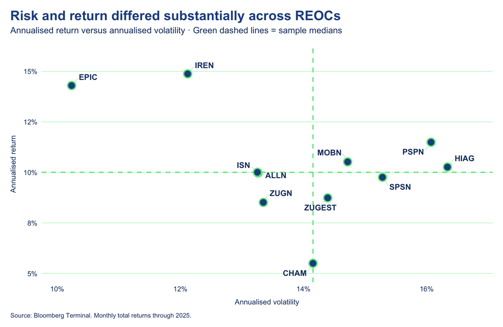

The firms occupy markedly different positions in risk–return space. EPIC and IREN combine comparatively high annualised returns with below-median volatility, whereas several firms with higher volatility generated more moderate returns. There is therefore no simple pattern in which greater risk was consistently accompanied by greater historical return.

## 2.3 Aggregate Sector Performance and Benchmark Comparison

The substantial differences across individual REOCs motivate the construction of aggregate sector measures. Two complementary portfolios are used: an **equal-weighted portfolio (EW)**, which gives each available firm the same monthly weight, and a **value-weighted portfolio (VW)**, which gives greater influence to larger companies through lagged market capitalization.

For month $t$, the equal-weighted portfolio return is

$$R_{EW,t} =
\frac{1}{N_t}
\sum_{i=1}^{N_t} R_{i,t},$$

where $N_t$ denotes the number of firms with an available return in month $t$.

The value-weighted portfolio return is

$$R_{VW,t} =
\sum_{i=1}^{N_t}
w_{i,t-1} R_{i,t},$$

where $w_{i,t-1}$ is firm $i$’s share of sample market capitalization based on the preceding observation.

The constructed portfolios are compared with two Bloomberg total-return benchmarks: the **SXI Real Estate Shares Broad Total Return Index (REAL)** and the **Swiss Performance Index Total Return (SPI TR)**.

### 2.3.1 Portfolio and Benchmark Performance

For direct comparison, both constructed portfolios and both external benchmarks are rebased to 100 at the beginning of their common observation period.

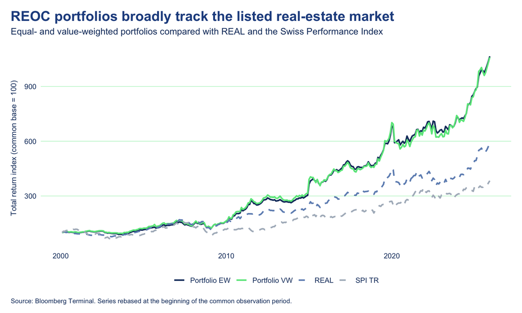

The equal- and value-weighted portfolios follow broadly similar long-run paths despite substantial differences in firm size. Their trajectories also resemble the dedicated listed real-estate benchmark more closely than the broad Swiss equity index.

### 2.3.2 Correlation with Swiss Market Benchmarks

Cumulative performance provides a visual comparison of long-run trajectories. Pearson correlations of monthly returns provide a more direct measure of co-movement with the two Swiss benchmarks.

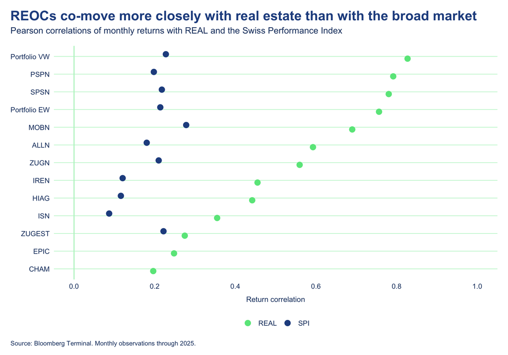

This external benchmark comparison supports the use of the EW and VW portfolios as aggregate measures of Swiss listed REOC market performance in the macroeconomic analysis that follows.

## 2.4 Market Concentration

The value-weighted portfolio gives larger firms greater influence, making market structure an important part of the analysis. We therefore examine how the distribution of market capitalization has evolved across the selected REOCs and how concentrated that distribution remains.

### 2.4.1 Evolution of Market Structure

The table summarizes the yearly market-capitalization structure of the selected sample. Firm weights are expressed as percentages of total observed sample market capitalization, while the **Top-3 share** and **Herfindahl–Hirschman Index (HHI)** provide complementary measures of aggregate concentration.

Table 3: Evolution of market-capitalization weights and concentration

| Year | No. firms | HHI | Top-3 share | ALLN | ISN | PSPN | SPSN | MOBN | ZUGEST | ZUGN | HIAG | IREN | CHAM | EPIC |
| --- | --- | --- | --- | --- | --- | --- | --- | --- | --- | --- | --- | --- | --- | --- |
| 2000 | 4 | 0.256 | 81.1% | 18.9% | 27.4% | 28.6% | 25.1% | — | — | — | — | — | — | — |
| 2001 | 4 | 0.269 | 84.4% | 15.6% | 27.0% | 34.8% | 22.6% | — | — | — | — | — | — | — |
| 2002 | 4 | 0.275 | 84.6% | 15.4% | 19.7% | 35.6% | 29.2% | — | — | — | — | — | — | — |
| 2003 | 4 | 0.286 | 87.7% | 22.2% | 12.3% | 38.6% | 27.0% | — | — | — | — | — | — | — |
| 2004 | 4 | 0.332 | 90.6% | 18.7% | 9.4% | 48.2% | 23.8% | — | — | — | — | — | — | — |
| 2005 | 5 | 0.281 | 84.3% | 17.8% | 7.9% | 42.1% | 24.4% | 7.7% | — | — | — | — | — | — |
| 2006 | 5 | 0.277 | 83.0% | 16.9% | 8.2% | 42.0% | 24.1% | 8.8% | — | — | — | — | — | — |
| 2007 | 5 | 0.251 | 79.5% | 20.9% | 9.3% | 37.8% | 20.8% | 11.1% | — | — | — | — | — | — |
| 2008 | 5 | 0.260 | 80.5% | 19.6% | 9.6% | 39.8% | 21.0% | 9.9% | — | — | — | — | — | — |
| 2009 | 5 | 0.265 | 82.7% | 15.9% | 7.1% | 30.8% | 36.0% | 10.2% | — | — | — | — | — | — |
| 2010 | 5 | 0.269 | 84.7% | 17.4% | 5.9% | 32.1% | 35.2% | 9.4% | — | — | — | — | — | — |
| 2011 | 5 | 0.262 | 82.6% | 16.6% | 6.0% | 32.0% | 34.1% | 11.4% | — | — | — | — | — | — |
| 2012 | 7 | 0.227 | 76.8% | 16.0% | 4.8% | 28.2% | 32.6% | 9.7% | 4.4% | 4.4% | — | — | — | — |
| 2013 | 7 | 0.224 | 75.9% | 15.6% | 5.6% | 27.4% | 33.0% | 9.1% | 4.7% | 4.7% | — | — | — | — |
| 2014 | 8 | 0.207 | 73.1% | 15.2% | 4.9% | 27.3% | 30.6% | 8.6% | 4.4% | 4.4% | 4.6% | — | — | — |
| 2015 | 8 | 0.214 | 72.7% | 13.3% | 5.0% | 25.3% | 34.1% | 8.6% | 4.6% | 4.6% | 4.6% | — | — | — |
| 2016 | 9 | 0.192 | 68.1% | 13.2% | 5.5% | 22.2% | 32.7% | 8.7% | 4.5% | 4.5% | 4.6% | 4.0% | — | — |
| 2017 | 9 | 0.192 | 68.1% | 13.5% | 5.0% | 21.7% | 32.9% | 8.3% | 4.8% | 4.8% | 5.0% | 4.1% | — | — |
| 2018 | 9 | 0.186 | 66.8% | 12.6% | 5.0% | 23.0% | 31.3% | 8.0% | 5.6% | 5.6% | 4.8% | 4.1% | — | — |
| 2019 | 9 | 0.200 | 69.3% | 12.0% | 4.2% | 24.0% | 33.3% | 7.5% | 5.8% | 5.8% | 3.4% | 4.1% | — | — |
| 2020 | 10 | 0.181 | 67.4% | 14.3% | 5.2% | 23.9% | 29.2% | 8.3% | 4.6% | 4.6% | 4.1% | 5.2% | 0.8% | — |
| 2021 | 10 | 0.179 | 66.8% | 14.6% | 5.0% | 22.7% | 29.5% | 8.7% | 4.4% | 4.4% | 4.2% | 5.8% | 0.7% | — |
| 2022 | 11 | 0.172 | 64.1% | 11.7% | 5.4% | 23.4% | 28.9% | 8.1% | 4.2% | 4.2% | 3.9% | 6.1% | 0.9% | 3.1% |
| 2023 | 11 | 0.183 | 66.0% | 11.1% | 5.2% | 24.1% | 30.8% | 8.5% | 3.7% | 3.7% | 3.6% | 5.6% | 0.8% | 3.0% |
| 2024 | 11 | 0.177 | 64.7% | 10.9% | 4.8% | 23.5% | 30.3% | 8.4% | 4.1% | 4.1% | 3.4% | 5.7% | 1.4% | 3.3% |
| 2025 | 11 | 0.173 | 62.9% | 10.7% | 5.0% | 20.9% | 31.3% | 8.6% | 3.6% | 3.6% | 3.8% | 5.9% | 3.5% | 3.1% |

**Note:** Firm columns report each company’s share of total observed sample market capitalization. A dash indicates that the firm is not observed in that year. The Top-3 share is the combined market-capitalization share of the three largest firms in each year; HHI is the sum of squared market shares.

By 2025, the market remains dominated by a relatively small group of firms. **Swiss Prime Site (SPSN)** accounts for approximately **31.3%** of sample market capitalization, followed by **PSP Swiss Property (PSPN)** at **20.9%** and **Allreal (ALLN)** at **10.7%**.

Together, the three largest firms represent approximately **62.9% of total sample market capitalization**. This concentration explains why firm size matters materially for the value-weighted portfolio and provides the empirical basis for the later property-level focus on these three companies.

31.3% **SWISS PRIME SITE**

20.9% **PSP SWISS PROPERTY**

10.7% **ALLREAL**

62.9% **TOP 3 COMBINED**

### 2.4.2 Evolution of Market Concentration

The yearly market structure can be summarized more directly using the **Top-3 market-capitalization share** and the **Herfindahl–Hirschman Index**. The two measures capture different aspects of the same phenomenon: the Top-3 share focuses on the dominant firms, while the HHI incorporates the full distribution of market weights.

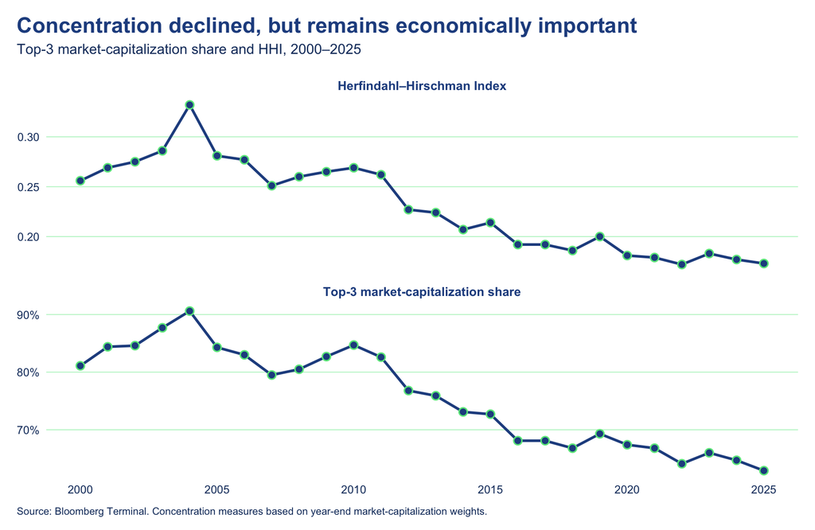

Both measures indicate a broad decline in concentration over the historical period. The Top-3 share fell from above 80% in the early 2000s to approximately **62.9% in 2025**, while the HHI declined to approximately **0.173**.

The market has therefore become more diversified over time, but concentration remains economically important: the three largest firms still account for nearly two-thirds of selected market capitalization.

**Interpretation note:** the number of observed firms increases over time. Early concentration values therefore partly reflect a smaller observed universe as well as the distribution of market capitalization among firms.

## 2.5 RQ1 — Chapter Findings

01  
FIRMS DIVERGED

Swiss listed REOCs differ substantially in **balance-sheet scale, leverage and market performance**. Several established firms expanded markedly, while capital-structure trajectories remained heterogeneous.

02  
RETURNS SHARE COMMON CYCLES

Firm-level returns frequently move in the same direction, but the magnitude of those movements varies. Aggregate REOC portfolios also co-move more closely with the **listed real-estate benchmark** than with the broader Swiss equity market.

03  
MARKET VALUE IS CONCENTRATED

Market concentration has declined over time, yet **Swiss Prime Site, PSP Swiss Property and Allreal still represent 62.9% of selected 2025 market capitalization**.

RQ1 therefore describes a sector that is **concentrated but heterogeneous**: aggregate market performance masks substantial differences in firm scale, financial structure and equity-market behaviour. The next chapter examines whether these market and firm-level outcomes are systematically associated with changes in the Swiss macroeconomic environment.

# 3 REOCs and the Macroeconomic Environment

How strongly does the Swiss macroeconomic environment appear in the performance and financial structure of listed real-estate companies? This chapter examines the relationship at two levels: first through **monthly market returns**, and then through **annual firm fundamentals**.

The analysis is primarily **associational**. Correlations and regression models identify historical relationships between REOCs and macroeconomic conditions, but they do not establish causal effects.

Interest rates receive particular attention because listed real estate combines capital-intensive businesses with publicly traded securities whose valuations can respond rapidly to changes in financing conditions and discount rates.

01

RQ2 · MARKET

Monthly REOC returns × macroeconomic changes

02

RQ3 · FUNDAMENTALS

Annual firm characteristics × macroeconomic environment

## 3.1 Market Performance and Macroeconomic Conditions — RQ2

RQ2

How is the stock-market performance of Swiss listed real-estate companies associated with changes in the macroeconomic environment?

The analysis focuses primarily on **short- and long-term Swiss interest rates**, complemented by inflation and labour-market conditions. Monthly portfolio returns are retained at their natural frequency so that changes in market conditions can be related directly to listed REOC performance.

### 3.1.1 Swiss Macroeconomic Environment

The sample spans fundamentally different monetary environments: declining rates after the early 2000s, the post-financial-crisis low-rate period, Switzerland’s negative-rate era and the sharp tightening beginning in 2022.

Because the monetary-policy framework changed over time, the short-term series combines the **3-month CHF LIBOR** with the **SNB policy rate**. The 10-year Swiss Confederation bond yield represents longer-term financing and discount-rate conditions.

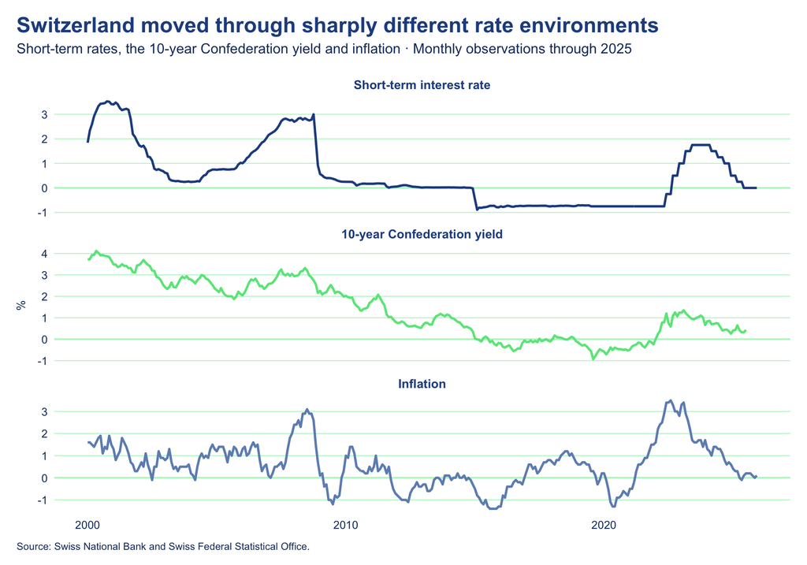

The figure shows a pronounced long-run decline in both short- and long-term interest rates, followed by an extended period of exceptionally low or negative short-term rates. The tightening cycle beginning in 2022 marked a clear reversal, accompanied by a temporary increase in inflation.

This variation provides the macroeconomic backdrop for examining whether REOC returns differ systematically across monetary environments and, more directly, with changes in interest rates.

### 3.1.2 REOC Returns Across Monetary Regimes

As a first descriptive comparison, the monthly sample is divided into five broad monetary regimes. These are **historical classifications rather than statistically estimated states** and are used only to summarize the distribution of REOC returns across distinct environments.

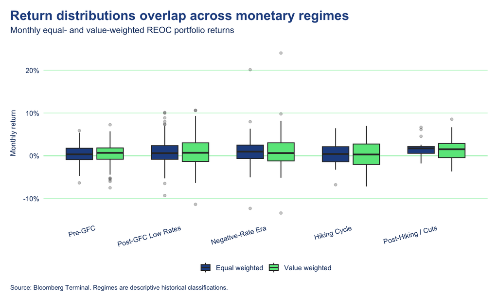

Monthly returns vary substantially **within every regime**, and the distributions overlap considerably. Broad monetary classifications therefore provide context, but they do not by themselves explain monthly REOC performance.

The next step examines the relationship more directly by relating portfolio returns to **month-to-month changes in interest rates**.

### 3.1.3 Portfolio Sensitivity to Macroeconomic Changes

Financial markets can react quickly to changes in financing conditions and discount rates. We therefore focus on contemporaneous monthly changes in short- and long-term interest rates rather than only their absolute levels.

Table 4: REOC returns are more closely associated with changes in long-term rates

| Portfolio | Change in short-term rate | Change in 10-year yield |
| --- | --- | --- |
| Equal weighted | -0.124 | -0.245 |
| Value weighted | -0.134 | -0.265 |

**Note:** Pearson correlations between monthly portfolio returns and monthly changes in Swiss interest rates. Negative values indicate that rising rates tend to coincide with weaker REOC returns.

The correlations are negative for both portfolio constructions, but the relationship is stronger for changes in the **10-year Confederation yield** than for changes in short-term rates. This suggests that longer-term discount-rate conditions are particularly relevant for listed REOC performance.

The relationship is shown directly below for the value-weighted portfolio.

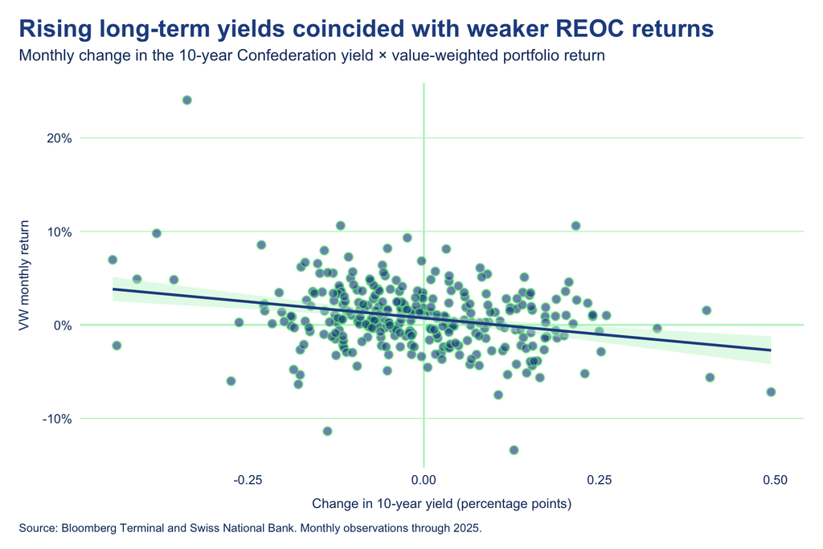

The fitted relationship is clearly downward sloping: months in which long-term Swiss government yields increased tended, on average, to coincide with weaker value-weighted REOC returns.

This remains an **association rather than a causal effect**. Interest rates and equity prices can respond simultaneously to economic news, expectations and other factors not explicitly modelled here.

A multivariable specification provides a broader check by considering short- and long-term rate changes, inflation and changes in unemployment simultaneously.

Table 5: Portfolio-level associations with macroeconomic conditions

| Portfolio | Macroeconomic variable | Estimate | Std. error | p-value |
| --- | --- | --- | --- | --- |
| Equal weighted | Change in short-term rate | -0.0207 | 0.0124 | 0.0967 |
| Equal weighted | Change in 10-year yield | -0.0508 | 0.0129 | 0.0001 |
| Equal weighted | Inflation | -0.0034 | 0.0017 | 0.0426 |
| Equal weighted | Change in unemployment | -0.1027 | 0.0241 | 0.0000 |
| Value weighted | Change in short-term rate | -0.0259 | 0.0143 | 0.0705 |
| Value weighted | Change in 10-year yield | -0.0634 | 0.0149 | 0.0000 |
| Value weighted | Inflation | -0.0031 | 0.0019 | 0.1128 |
| Value weighted | Change in unemployment | -0.1161 | 0.0277 | 0.0000 |

**Note:** OLS regressions of monthly portfolio returns on contemporaneous macroeconomic variables. Coefficients represent conditional historical associations and should not be interpreted causally.

The multivariable models test whether the interest-rate relationships remain visible once several macroeconomic indicators are considered jointly. The long-term yield remains the most economically relevant rate variable in the portfolio-level results.

The evidence up to this point therefore points to a consistent pattern: **REOC returns tend to weaken when long-term Swiss yields rise**, although macroeconomic conditions explain only part of the substantial month-to-month variation in listed real-estate performance.

### 3.1.4 3.1.4 Firm Heterogeneity

Aggregate portfolio results can conceal differences between individual companies. We therefore estimate the relationship between monthly returns and changes in the long-term government yield separately for each REOC.

Inflation is included as an additional control, following the exploratory firm-level analysis.

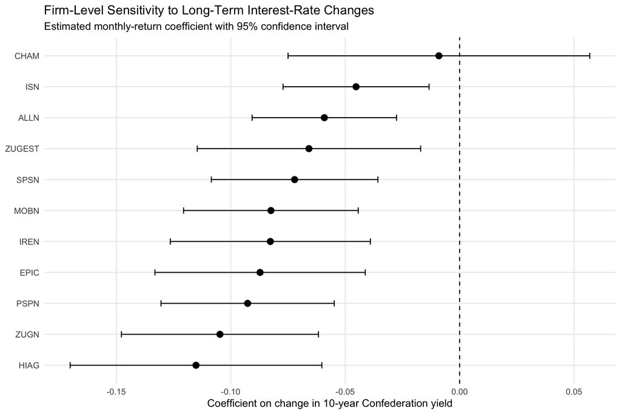

The firm-level estimates indicate that interest-rate sensitivity is not identical across REOCs. The magnitude of the estimated relationship differs across companies, although the general direction of the long-rate effect is predominantly negative.

This heterogeneity suggests that company-specific characteristics may influence how changes in financing and discount-rate conditions are transmitted into listed REOC returns.

### 3.1.5 3.1.5 RQ2 Findings

**RQ2: How is the stock-market performance of Swiss listed real-estate companies associated with changes in the macroeconomic environment?**

The results provide evidence that Swiss listed REOC market performance is associated with changes in the macroeconomic environment, with the clearest relationship appearing for long-term interest rates.

Both the equal-weighted and value-weighted portfolios exhibit negative correlations with changes in the 10-year Swiss Confederation yield. The value-weighted scatterplot similarly indicates that months of rising long-term yields tend to coincide with weaker REOC returns.

At the same time, return distributions overlap substantially across broad monetary regimes, and the magnitude of estimated interest-rate sensitivity differs across firms. The macroeconomic environment therefore appears relevant for REOC market performance, but the relationship is neither deterministic nor identical across companies.

These findings motivate the second part of the chapter, which examines whether macroeconomic conditions are also associated with changes in the underlying financial characteristics of REOCs.

## 3.2 3.2 Firm Fundamentals and Macroeconomic Conditions — RQ3

**RQ3: How are the financial characteristics of Swiss listed real-estate companies associated with changes in the macroeconomic environment?**

While RQ2 examines how financial markets respond to macroeconomic conditions at monthly frequency, RQ3 shifts the focus to the underlying companies.

The annual firm-level analysis focuses particularly on leverage because financing is central to the operation of real-estate companies. Profitability is considered as a second dimension through return on assets (ROA).

The annual analysis is restricted to 2001–2025 because later observations do not represent complete historical years.

### 3.2.1 3.2.1 Long-Term Interest Rates and Leverage

The exploratory correlation analysis identified the 10-year Swiss Confederation yield as the macroeconomic variable with the strongest pooled association with debt-to-assets.

We therefore examine this relationship in greater detail.

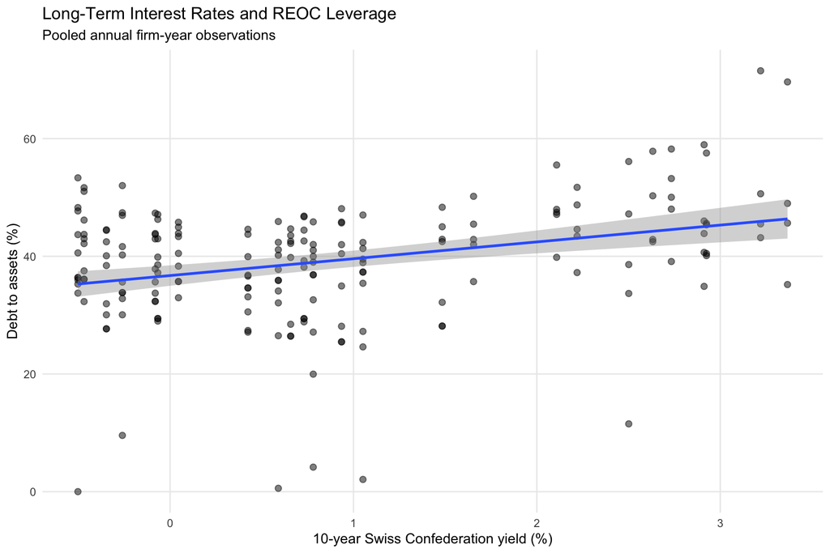

The pooled relationship is positive: firm-year observations recorded during periods of higher long-term Swiss government yields also tend to exhibit higher debt-to-assets ratios.

The pooled Pearson correlation is approximately **0.32**. This is the strongest relationship between leverage and the core macroeconomic indicators considered in the exploratory correlation analysis.

However, a relationship between the **levels** of two variables does not necessarily imply that firms increase leverage when interest rates rise. Persistent firm differences and long-run trends may generate such an association.

### 3.2.2 3.2.2 Levels Versus Changes

To distinguish the pooled level relationship from shorter-run adjustments, we compare annual changes in the 10-year Confederation yield with annual changes in debt-to-assets.

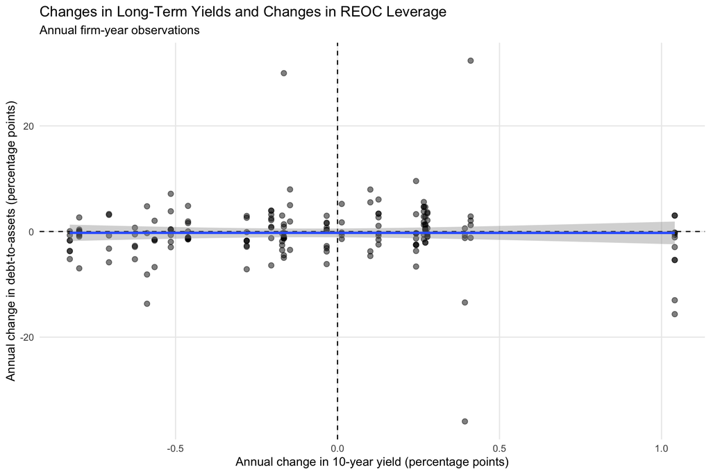

The relationship changes substantially when annual differences are considered. While the correlation between the **levels** of the 10-year yield and debt-to-assets is approximately **0.32**, the correlation between their annual changes is approximately zero.

This distinction is important. The pooled level relationship therefore does not provide evidence that REOCs systematically increase leverage in years when long-term interest rates rise.

Instead, the positive level relationship may reflect persistent differences between firms, longer-term historical developments, or other factors evolving alongside interest rates.

### 3.2.3 3.2.3 Firm Fixed-Effects Evidence

Panel regression provides a more formal way to distinguish pooled relationships from variation within individual firms.

We compare a pooled OLS regression with a firm fixed-effects model. The fixed-effects specification controls for persistent characteristics of each REOC and therefore asks whether leverage tends to vary with the long-term yield **within the same firm over time**.

```
##                   model_leverage_..     model_levera.. model_leverage_cha..
##                          Pooled OLS Firm Fixed Effects       Annual Changes
## Dependent Var.:      debt_to_assets     debt_to_assets delta_debt_to_assets
##
## Constant          36.73*** (0.8804)                        -0.2596 (0.3259)
## confederation_10y 2.859*** (0.6161)      1.736 (1.184)
## delta_10y_yield                                            -0.0075 (0.8708)
## Fixed-Effects:    -----------------     -------------- --------------------
## ticker                           No                Yes                   No
## _________________ _________________     ______________ ____________________
## S.E. type                       IID         by: ticker           by: ticker
## Observations                    192                192                  181
## R2                          0.10181            0.61284              3.93e-7
## Within R2                        --            0.07548                   --
## ---
## Signif. codes: 0 '***' 0.001 '**' 0.01 '*' 0.05 '.' 0.1 ' ' 1
```

The pooled OLS model indicates a positive and statistically significant relationship between the 10-year yield and leverage. A one-percentage-point higher long-term yield is associated with approximately **2.86 percentage points higher debt-to-assets** in the pooled sample.

Once firm fixed effects are introduced, however, the estimated coefficient declines to approximately **1.74** and is no longer statistically significant.

The first-difference specification similarly provides little evidence that annual increases in long-term yields are systematically accompanied by annual increases in leverage.

Together, these results indicate that a substantial part of the positive pooled relationship reflects persistent differences between firms and longer-term historical patterns rather than a uniform short-run leverage response to changing interest rates.

### 3.2.4 3.2.4 Heterogeneity Across REOCs

The weakening of the pooled relationship after controlling for firm effects suggests that REOCs may differ substantially in their individual yield–leverage relationships.

We therefore calculate the correlation between the 10-year Confederation yield and debt-to-assets separately for each company.

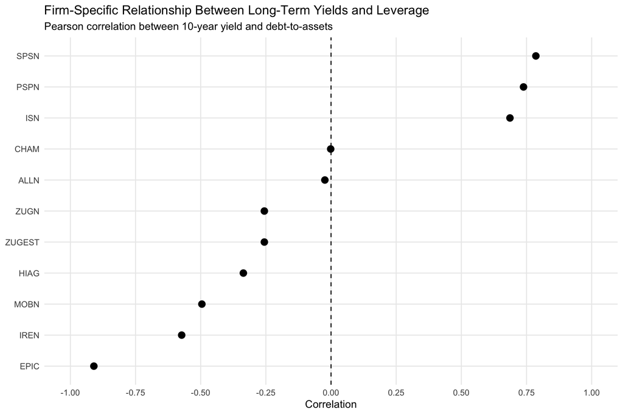

The firm-specific correlations reveal substantial heterogeneity. Some companies exhibit strongly positive historical relationships between long-term yields and leverage, while others display weak or negative relationships.

Among firms with long histories, Swiss Prime Site and PSP Swiss Property exhibit strong positive associations, whereas several other REOCs show materially different patterns.

Estimates for companies with short histories should be interpreted cautiously because they are based on substantially fewer annual observations.

Overall, the heterogeneity helps explain why the pooled relationship weakens after persistent firm-specific characteristics are taken into account.

### 3.2.5 3.2.5 Profitability and Economic Growth

Leverage is not the only financial characteristic that may respond to macroeconomic conditions. We also examine whether firm profitability is related to Swiss economic growth.

Because raw net income is not directly comparable across companies of different sizes, profitability is measured using **return on assets (ROA)**, defined as net income relative to total assets.

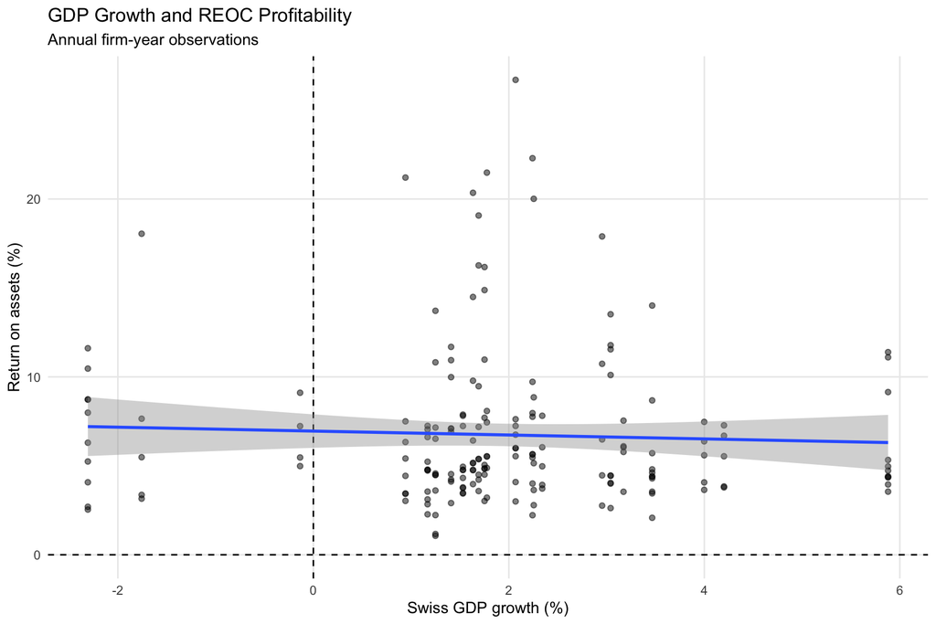

The relationship between Swiss GDP growth and REOC profitability is weak. High and low ROA observations occur under a range of GDP-growth environments, and the pooled correlation is close to zero.

Aggregate GDP growth therefore appears to explain relatively little of the variation in firm profitability observed in the sample.

This result is consistent with the broader analysis of firm fundamentals, which suggests that company-specific characteristics are often more important than a single common macroeconomic variable for explaining differences across REOCs.

### 3.2.6 3.2.6 RQ3 Findings

**RQ3: How are the financial characteristics of Swiss listed real-estate companies associated with changes in the macroeconomic environment?**

The analysis provides limited evidence of a uniform relationship between macroeconomic conditions and the financial characteristics of Swiss listed REOCs.

The clearest pooled relationship is between the 10-year Swiss Confederation yield and debt-to-assets. Higher long-term yields are associated with higher leverage when firm-year observations are pooled.

However, this relationship becomes substantially weaker when the analysis focuses on annual changes or controls for persistent differences between firms. The firm fixed-effects estimate is smaller and no longer statistically significant, while changes in long-term yields exhibit almost no correlation with annual changes in leverage.

Firm-specific relationships also differ considerably in both magnitude and direction. Similarly, Swiss GDP growth shows little pooled relationship with firm profitability.

The results therefore suggest that the macroeconomic environment is related to some REOC financial characteristics, but these relationships are heterogeneous and should not be interpreted as common causal responses across firms.

## 3.3 3.3 Overall Chapter Findings

RQ2 and RQ3 provide complementary perspectives on the relationship between Swiss listed real estate and the macroeconomic environment.

At the **market level**, REOC returns appear relatively responsive to changes in interest rates. In particular, increases in long-term Swiss government yields tend to coincide with weaker monthly returns for both the equal-weighted and value-weighted portfolios. The effect is also visible across individual companies, although its magnitude differs between REOCs.

At the **firm-fundamental level**, the evidence is less uniform. A positive pooled relationship exists between long-term yields and leverage, but this relationship weakens substantially once persistent firm differences and annual changes are considered. GDP growth likewise explains relatively little of the observed variation in profitability.

Taken together, the findings suggest that macroeconomic conditions are reflected more immediately in **market valuations and returns** than in uniform short-run changes in **corporate financial structure**.

Firm heterogeneity remains important in both parts of the analysis. Swiss listed REOCs differ in their market sensitivity, leverage dynamics and historical relationships with macroeconomic variables. This heterogeneity provides an additional reason to complement the market-wide analysis with a closer examination of individual companies and their underlying property portfolios.

# 4 4. Chapter of Choice — Building a Property-Level Dataset

The financial and market analyses in the previous chapters describe listed real-estate companies primarily through accounting variables, market capitalization and stock returns. However, these companies ultimately derive their value from portfolios of physical real-estate assets.

To complement the financial analysis, this chapter develops a property-level dataset for the three largest companies in the selected REOC sample: **Swiss Prime Site (SPSN), PSP Swiss Property (PSPN), and Allreal (ALLN)**.

Unlike the firm-level Bloomberg dataset, no single standardized source contained comparable property-level observations for all three companies. The dataset therefore had to be constructed from company webpages and annual-report disclosures.

This chapter constitutes the **Chapter of Choice** because it applies methods beyond the standard data-manipulation and visualization techniques used elsewhere in the report. In particular, the workflow combines:

- web scraping with `rvest`;
- PDF text and coordinate extraction with `pdftools`;
- regular-expression-based parsing and address standardization;
- geocoding with `tidygeocoder` and OpenStreetMap/Nominatim; and
- interactive spatial visualization with `leaflet`.

The result is a combined geocoded dataset that connects the financial characteristics of the largest Swiss listed REOCs to the physical assets underlying their portfolios.

## 4.1 4.1 Motivation

Chapter 2 showed that the Swiss listed REOC market is highly concentrated. In 2025, Swiss Prime Site, PSP Swiss Property and Allreal together represented approximately 62.9% of the market capitalization of the selected sample.

This makes the three companies particularly relevant for a more detailed examination.

Financial statements can show how large these companies are, how much debt they use and how their shares perform. They do not, however, directly show **where the underlying properties are located, how old they are, or how the physical portfolios differ across companies**.

A property-level dataset therefore allows the analysis to move from financial securities to the underlying real-estate assets.

The main challenge was that the three companies disclose their portfolios differently. PSP and Swiss Prime Site provide information through company webpages, while detailed variables are also available in company reports. Allreal similarly publishes property information in report format. These sources differ in structure and therefore require different extraction and cleaning approaches.

The objective of the data-engineering workflow was to convert these heterogeneous disclosures into a comparable structure containing, where available:

- company and property identifiers;
- address and city;
- construction year;
- property or land area;
- property type or use;
- latitude; and
- longitude.

## 4.2 4.2 Extracting Property Information

### 4.2.1 4.2.1 PSP Swiss Property — Web Scraping and Report Matching

For PSP Swiss Property, the current property portfolio was first extracted from the company’s online property portfolio.

The `rvest` package was used to read the webpage and identify links and images corresponding to individual property objects. Address information was obtained from the property labels associated with the portfolio images.

The essential structure of the web-scraping step was:

```r
library(rvest)

url <-
  "https://www.psp.info/en/portfolio/investment-properties/all-properties"

page <- read_html(url)

property_images <- page |>
  html_elements("img")

property_labels <- property_images |>
  html_attr("alt")
```

Only image elements that represented identifiable properties were retained. The associated hyperlink was then extracted from the surrounding HTML element, creating one observation per property with a source URL.

```r
PSPN_properties <- tibble(

  property_label =
    property_images |>
    html_attr("alt"),

  href =
    property_images |>
    html_element(
      xpath =
        "ancestor::a[contains(@href, '/portfolio/object/')][1]"
    ) |>
    html_attr("href")
)
```

The resulting property labels were separated into address and city fields and standardized before geocoding.

A stable property identifier was also created for every observation, for example `PSPN_001`, `PSPN_002`, and so forth.

The scraped geographic dataset was subsequently matched with PSP’s 2025 report data. Since addresses were formatted differently across the website and report, an address-normalization function was used to remove accents, punctuation differences and inconsistent whitespace before constructing matching keys.

```r
normalize_address <- function(x) {

  x |>
    str_to_lower() |>
    stringi::stri_trans_general(
      "Latin-ASCII"
    ) |>
    str_replace_all(
      "[/,-]",
      " "
    ) |>
    str_replace_all(
      "[^a-z0-9 ]",
      " "
    ) |>
    str_squish()
}
```

This step combined the location information obtained online with property characteristics from the annual report, including variables such as construction year and rentable area.

### 4.2.2 4.2.2 Swiss Prime Site — Extracting Structured Tables from PDF Coordinates

Swiss Prime Site required a different approach because important property-level variables were contained in structured PDF tables.

Simply extracting plain text from a PDF often destroys the table structure. To overcome this problem, the workflow used `pdftools::pdf_data()`, which returns individual words together with their positions on each PDF page.

```r
library(pdftools)

SPSN_pdf_data <-
  pdf_data(
    "SPSN_Property_Report_2025.pdf"
  )
```

The horizontal position of each word was then used to reconstruct the original table columns.

For example, words located within particular x-coordinate intervals were interpreted as belonging to fields such as property name, rental income, ownership status, construction year, site area and commercial area.

A simplified version of the column-extraction logic is:

```r
get_col <- function(
  data,
  lower,
  upper = Inf
) {

  data |>
    filter(
      x >= lower,
      x < upper
    ) |>
    arrange(x) |>
    pull(text) |>
    paste(
      collapse = " "
    ) |>
    str_squish()
}
```

This technique enabled the PDF disclosure to be converted into a structured property table rather than treating each page as unstructured text.

The resulting dataset included variables such as:

- reported property name;
- ownership status;
- year of construction;
- year of renovation;
- site area;
- commercial area;
- rental-income information; and
- property-use shares.

Additional cleaning was required to remove report totals, building land, development projects and properties that had been sold during the reporting period.

This highlights an important feature of data extraction from corporate disclosures: **successful parsing does not automatically imply a valid analytical dataset**. The extracted records still had to be checked against the economic definition of the portfolio being analysed.

### 4.2.3 4.2.3 Allreal — PDF Text Extraction and Regular-Expression Parsing

Allreal’s property information required a third extraction strategy.

The report was read using `pdftools::pdf_text()`. Unlike the coordinate-based Swiss Prime Site extraction, the Allreal tables could be parsed from the textual structure of the relevant report pages.

```r
ALLN_pdf <-
  pdf_text(
    "ALLN_Property_Report_2025.pdf"
  )

residential_text <-
  paste(
    ALLN_pdf[1],
    ALLN_pdf[2],
    sep = "\n"
  )

residential_lines <-
  residential_text |>
  str_split("\n") |>
  unlist() |>
  str_squish()
```

Rows corresponding to actual properties were identified using recurring ownership codes in the report.

Regular expressions were then used to separate fields such as:

- ownership status;
- acquisition year;
- construction year;
- location;
- address;
- floor space;
- apartment counts;
- target rental income; and
- vacancy information.

Residential and commercial properties were parsed separately and subsequently combined into a single Allreal property dataset.

The different extraction methods used across the three companies reflect the lack of a standardized reporting format. Rather than forcing all sources through the same extraction method, the workflow adapted the method to the structure of each source.

## 4.3 4.3 Cleaning and Standardizing Addresses

Property addresses were not immediately suitable for spatial analysis.

Corporate disclosures frequently contain multi-building addresses such as:

`Bahnhofplatz 1, 2 / Bahnhofquai 9, 11, 15`

or address ranges such as:

`Grabenstrasse 17, 19`.

These formats are informative for a human reader but can reduce the success rate of automated geocoding services.

The cleaning process therefore created simplified versions of complex addresses while retaining the original reported address in the dataset.

Typical transformations included:

- selecting the first street from multi-street properties;
- retaining the first house number from multi-number addresses;
- removing building or project descriptions;
- standardizing whitespace;
- harmonizing city names; and
- appending `"Switzerland"` to improve geographic specificity.

For example:

```r
properties <- properties |>
  mutate(

    simplified_address =
      address |>
      str_remove(
        "\\s*/.*$"
      ) |>
      str_replace(
        "(\\d+[A-Za-z]?)(\\s*,\\s*\\d+[A-Za-z]?)+$",
        "\\1"
      ) |>
      str_squish(),

    simplified_full_address =
      paste(
        simplified_address,
        city,
        "Switzerland",
        sep = ", "
      )
  )
```

The objective was not to replace the official property address. The original disclosure remained available, while the simplified field acted only as a technical input for geocoding.

## 4.4 4.4 Geocoding the Property Portfolios

Once addresses had been standardized, they were converted into geographic coordinates.

The `tidygeocoder` package was used with the OpenStreetMap/Nominatim geocoding service.

A typical geocoding call was:

```r
properties_geo <- properties |>
  tidygeocoder::geocode(
    address =
      simplified_full_address,
    method = "osm",
    lat = latitude,
    long = longitude
  )
```

which provide the geographic position required for mapping.

### 4.4.1 4.4.1 Multi-Pass Geocoding

Not every corporate address could be geocoded successfully on the first attempt.

The workflow therefore used a **multi-pass geocoding strategy**.

First, the original or automatically simplified address was submitted to the geocoder.

Second, addresses with missing coordinates were simplified further. For example, building names were removed, ranges were reduced to a single house number and multi-address properties were reduced to one representative address.

Finally, a small number of problematic observations were assigned manually cleaned geocoding strings and submitted again to the same geocoding service.

The logic used to combine successive attempts was:

```r
properties_geo <- properties_geo |>
  left_join(
    second_pass_coordinates,
    by = "property_id"
  ) |>
  mutate(
    latitude =
      coalesce(
        latitude,
        latitude_new
      ),
    longitude =
      coalesce(
        longitude,
        longitude_new
      )
  )
```

This process is important because a failed geocoding request does not necessarily imply that the reported property is invalid. It often reflects formatting differences between corporate disclosures and the address representation expected by the geocoding service.

## 4.5 4.5 Final Property-Level Dataset

For reproducibility, the time-consuming web-scraping, PDF extraction and geocoding processes are separated from the final report.

The final cleaned datasets are saved as CSV files and loaded directly when the report is knitted.

The final property datasets contain approximately:

Final property-level datasets for the three largest REOCs

| Company | Ticker | Property observations |
| --- | --- | --- |
| PSP Swiss Property | PSPN | 150 |
| Swiss Prime Site | SPSN | 122 |
| Allreal | ALLN | 74 |

The final datasets contain approximately **150 PSP observations, 122 Swiss Prime Site observations and 74 Allreal observations**.

The term *property observation* is preferable to assuming that every reporting row necessarily corresponds to one physically separate building. A reported property can contain several addresses or buildings within a single investment property.

The precise variable set differs somewhat across companies because the underlying corporate disclosures differ. However, all three datasets contain the common geographic information required for combined spatial analysis.

### 4.5.1 4.5.1 Geocoding Completeness

Before using coordinates for mapping, the final datasets are checked for missing latitude or longitude values.

Geocoding completeness of the final property datasets

| Company | Property observations | Geocoded observations | Geocoding rate |
| --- | --- | --- | --- |
| PSP Swiss Property | 150 | 150 | 100.0% |
| Swiss Prime Site | 122 | 122 | 100.0% |
| Allreal | 74 | 74 | 100.0% |

## 4.6 4.6 Interactive Mapping with Leaflet

The addition of latitude and longitude coordinates allows the property portfolios to be analysed spatially.

The `leaflet` package is used because it creates an interactive map directly within the HTML report. Unlike a static `ggplot2` figure, the reader can:

- zoom and pan across Switzerland;
- click individual properties;
- inspect property information in popups; and
- activate or deactivate the three company portfolios separately.

The following map combines all three final datasets.

[interactive chart not shown]

The map reveals the geographic footprint underlying the three largest listed REOCs. Rather than representing an abstract financial index, the companies consist of portfolios of physical assets concentrated in particular Swiss urban and economic regions.

The interactive layer control also makes it possible to compare the geographic footprint of the three portfolios directly.

## 4.7 4.8 Methodological Limitations

The property-level dataset should be interpreted with several limitations in mind.

First, the three companies do not disclose their portfolios using identical definitions or variables. Consequently, not every property characteristic is directly comparable across all three firms.

Second, a reporting row does not necessarily correspond to a single physical building. Some observations contain multiple addresses, adjoining buildings or larger property complexes.

Third, geocoding complex property addresses requires simplification. The coordinates should therefore be interpreted primarily as representative property locations rather than cadastral-level geographic precision.

Fourth, web-based information can change over time. The final CSV datasets preserve a reproducible snapshot of the information used for this project, while the original source URLs and report disclosures document where the information originated.

Finally, the property-level dataset focuses on the three largest companies and is therefore not intended to represent the full Swiss listed real-estate universe.

## 4.8 4.9 Chapter of Choice — Conclusion

This chapter demonstrates how heterogeneous corporate disclosures can be transformed into a structured and spatially analysable dataset.

Different source formats required different extraction techniques. PSP’s online portfolio was accessed through web scraping with `rvest`; Swiss Prime Site’s structured PDF tables were reconstructed using positional information from `pdftools`; and Allreal’s report was parsed from extracted PDF text.

After cleaning and harmonization, property addresses were geocoded with `tidygeocoder` and OpenStreetMap/Nominatim. The resulting coordinates enabled the construction of an interactive `leaflet` map containing the three largest REOC property portfolios.

The final datasets comprise approximately **150 PSP, 122 Swiss Prime Site and 74 Allreal property observations** and connect the financial analysis of listed companies to the physical real-estate assets underlying them.

This workflow extends the project beyond conventional financial-data analysis and demonstrates how web data, PDF disclosures and spatial information can be combined within R to create a new dataset for further empirical analysis.

# 5 5. Top-3 REOC Deep Dive and Conclusion

The previous chapters examined Swiss listed real-estate companies from three perspectives: their long-run financial development, their market performance, and their relationship with the macroeconomic environment.

This final chapter brings these perspectives together by focusing on the three largest companies in the selected sample: **Swiss Prime Site (SPSN), PSP Swiss Property (PSPN), and Allreal (ALLN)**.

Together, these firms represented approximately **62.9% of the selected sample’s market capitalization in 2025**. Their importance to the listed sector therefore makes them suitable for a more detailed comparison.

The property-level dataset constructed in Chapter 4 makes it possible to complement financial and stock-market information with characteristics of the physical portfolios underlying the companies. The analysis considers portfolio scale, use composition, property age, geographic concentration, physical scale, market performance across macroeconomic regimes, and interest-rate sensitivity.

The purpose is not to rank the companies, but to examine whether three firms that dominate the same listed real-estate market nevertheless represent materially different underlying exposures.

## 5.1 5.1 The Top 3 in Financial and Physical Context

We begin by combining selected financial and physical characteristics into a single company profile.

The table reports the firms’ 2025 market-capitalization weight within the selected REOC sample, total assets, leverage and number of reported property observations.

Financial and physical profile of the three largest REOCs

| Company | 2025 Market Weight | Total Assets | Debt / Assets | Property Observations |
| --- | --- | --- | --- | --- |
| Swiss Prime Site | 31.3% | 15’781 | 39.9% | 122 |
| PSP Swiss Property | 20.9% | 10’929 | 33.1% | 150 |
| Allreal | 10.7% | 6’442 | 44.6% | 74 |

The comparison immediately illustrates an important distinction. The three companies dominate the selected listed REOC market in financial terms, but the number of underlying property observations differs substantially.

PSP reports approximately 150 property observations, Swiss Prime Site 122 and Allreal 74. Property counts should not be interpreted as measures of portfolio value because individual assets differ greatly in size, location and use. They nevertheless provide a first indication that similar market importance does not imply identical physical portfolio structures.

## 5.2 5.2 Portfolio Use Composition

Property count alone says little about the economic function of the underlying real estate. We therefore compare how reported floor or rentable area is distributed across broad property-use categories.

Because the three companies use different reporting classifications, the original categories are harmonized into five broad groups:

- **Office**
- **Retail**
- **Residential / Living**
- **Hospitality**
- **Other**

The harmonization is necessarily approximate. It is intended to provide a broad comparison rather than imply perfectly identical reporting definitions across companies.

### 5.2.1 5.2.1 Constructing Comparable Use Categories

For PSP Swiss Property, reported square metres are directly available for office, retail, gastronomy and other uses.

For Swiss Prime Site, use-specific areas are estimated by multiplying reported commercial area by the reported percentage allocated to each use.

For Allreal’s commercial properties, use-specific areas are similarly estimated from floor space and reported use percentages. Allreal properties classified as residential are assigned their reported residential floor space to the residential category.

### 5.2.2 5.2.2 Portfolio Use Mix

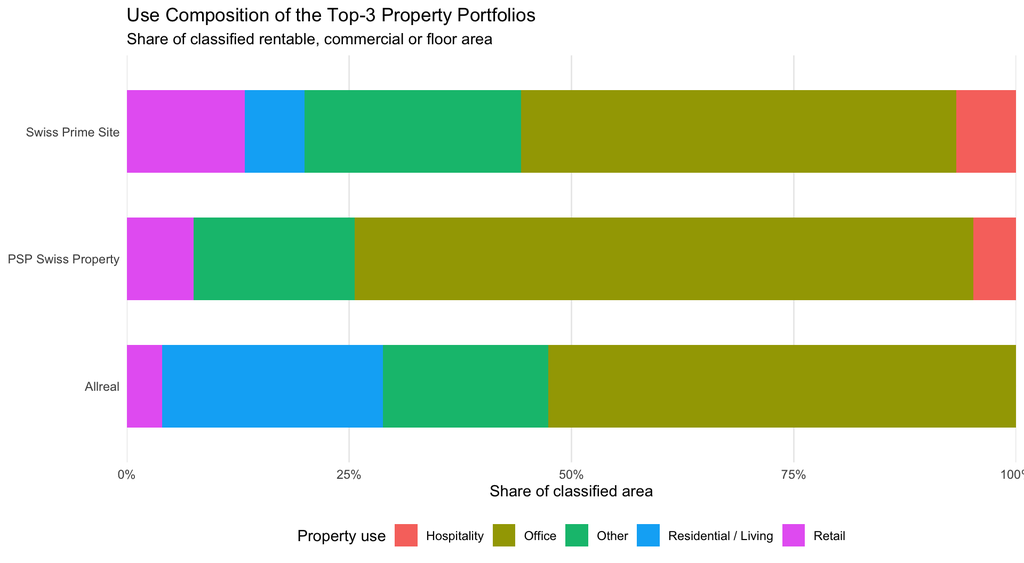

The 100% stacked bars reveal differences in the economic composition of the portfolios that are not visible from company size alone.

The chart should be interpreted as a comparison of **reported and harmonized area categories**, rather than as a perfectly standardized property classification. Nevertheless, it illustrates that the three listed firms provide different combinations of office, retail, residential and other real-estate exposure.

This is important from an investor perspective because property-use composition can influence rental-income stability, tenant structure and exposure to different parts of the economic cycle.

## 5.3 5.3 Portfolio Age

The age distribution of the portfolios provides a second dimension along which the three companies differ.

Construction years are extracted from each company’s property-level data. Where a disclosure contains more than one construction year, the first reported four-digit year is used as a simplified reference point.

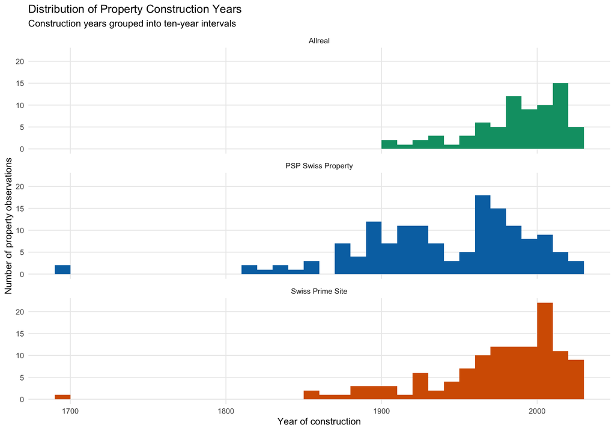

The distributions demonstrate that portfolio age is not uniform across the three firms.

Rather than relying only on an average construction year, the histogram shows both the central concentration and the historical tails of each portfolio. PSP in particular contains properties spanning a broad range of construction periods, while the Allreal dataset is more concentrated in comparatively recent construction periods.

These differences may reflect distinct acquisition histories, redevelopment strategies and geographic specializations.

## 5.4 5.4 Geographic Concentration

The property-level dataset also allows the geographic concentration of the three portfolios to be compared directly.

City names are first harmonized so that alternative language versions such as Zürich and Zurich or Genève and Geneva are treated as the same location.

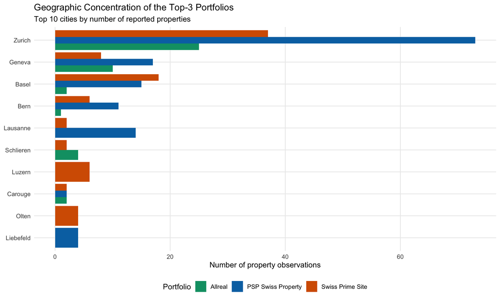

The firms have materially different geographic footprints. PSP has particularly substantial exposure to Zurich, while the relative importance of Basel, Geneva, Lausanne and other locations differs across the three portfolios.

The interactive map in **Chapter 4.6** provides the complementary spatial view and allows individual property locations to be inspected directly.

Together, the city comparison and interactive map indicate that concentration in the same listed market does not translate into identical geographic real-estate exposure.

## 5.5 5.5 Physical Scale and Development Intensity

Portfolio composition and location can be complemented by the physical scale of individual properties.

For this comparison, the reported site or land area is plotted against the corresponding rentable, commercial or floor area.

The source terminology differs across firms:

- PSP reports land area and rentable area;
- Swiss Prime Site reports site area and commercial area;
- Allreal reports site area and floor space.

The variables are therefore treated as approximately comparable indicators of **land footprint** and **usable property area**, rather than as perfectly identical accounting definitions.

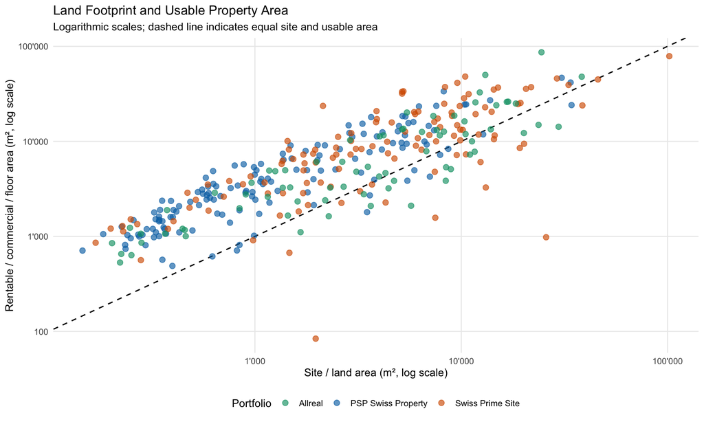

The diagonal reference line represents properties for which reported usable area equals the reported site or land area.

Observations above the line have more reported usable floor area than land area, which can be consistent with more intensive or multi-storey development. Observations below the line have a larger land footprint relative to their reported usable area.

Because the underlying companies use different reporting definitions, the figure should be interpreted as a broad physical comparison rather than a precise measure of development density. Even with this limitation, the dispersion illustrates substantial heterogeneity in the scale and physical structure of individual assets.

## 5.6 5.6 Top-3 Performance Across Macroeconomic Regimes

The physical portfolios differ, but the three firms also operate in the same financial and macroeconomic environment.

Chapter 3 showed that aggregate REOC returns vary across monetary regimes and that changes in long-term Swiss government yields are particularly relevant for listed real-estate returns.

We therefore return to the five macroeconomic regimes defined in Chapter 3 and compare the **average monthly return of each Top-3 firm** within each period.

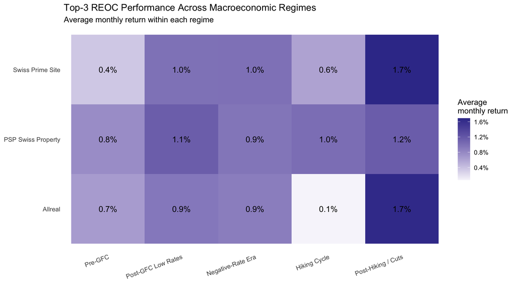

The heatmap allows the same macroeconomic environments to be compared across firms without reducing each company’s experience to one full-sample return measure.

Differences across rows indicate that companies exposed to the same Swiss interest-rate environment did not necessarily generate identical market outcomes. This is consistent with the firm-level heterogeneity identified in Chapter 3.

The comparison is descriptive: the regime averages combine many influences beyond monetary policy, including market-wide shocks, changes in portfolio composition and company-specific developments.

## 5.7 5.7 Interest-Rate Sensitivity of the Top 3

The regime analysis can be complemented by a more direct measure of interest-rate sensitivity.

Chapter 3 examined monthly stock returns against changes in the 10-year Swiss Confederation yield. Here, the same relationship is estimated only for the three dominant companies.

Inflation is retained as an additional control to make the estimates consistent with the firm-level specification used in Chapter 3.

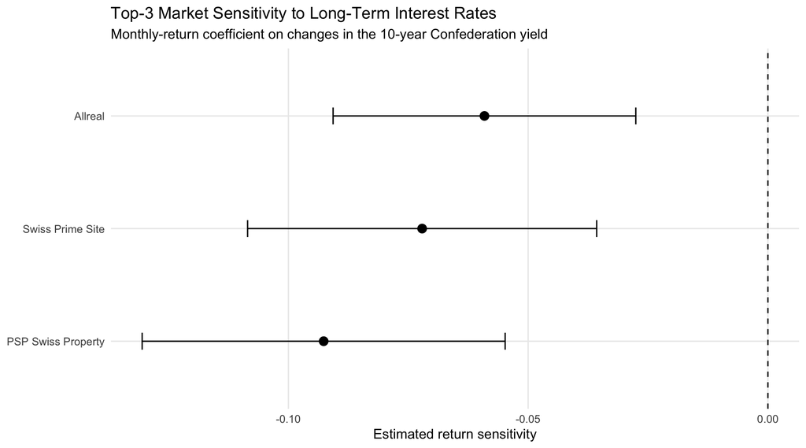

The estimates make the distinction between **sector exposure** and **company-specific exposure** explicit. All three companies operate within the same listed real-estate market, but the magnitude of the historical relationship between their returns and changes in long-term yields is not identical.

The confidence intervals also provide an indication of estimation uncertainty rather than presenting the individual coefficients as exact sensitivities.

### 5.7.1 5.7.1 Interest Rates and Financial Structure

The market-response analysis can be compared with the leverage relationships identified in RQ3.

Firm-specific relationship between long-term government yields and leverage

| Company | Observations | Yield–Leverage Correlation |
| --- | --- | --- |
| Allreal | 25 | -0.02 |
| PSP Swiss Property | 25 | 0.74 |
| Swiss Prime Site | 25 | 0.79 |

This comparison reinforces the broader finding from Chapter 3: the same macroeconomic variable can be associated differently with different companies.

Swiss Prime Site and PSP Swiss Property display relatively strong positive historical relationships between long-term yields and leverage, whereas Allreal’s relationship is substantially weaker.

The combination of market-return and balance-sheet evidence therefore argues against treating the Top-3 firms as interchangeable exposures.

## 5.8 5.8 Bringing Financial and Physical Portfolios Together

The Top-3 analysis brings together the main strands of the report.

At the **market level**, Swiss Prime Site, PSP Swiss Property and Allreal account for a substantial majority of the market capitalization of the selected listed REOC sample.

At the **property level**, however, their portfolios differ along several dimensions:

- the number of reported properties;
- geographic concentration;
- property-use composition;
- construction-year distribution; and
- the relationship between land footprint and usable property area.

At the **financial level**, the firms also differ in leverage and in the historical relationship between their balance sheets and long-term government yields.

Finally, at the **equity-market level**, their returns do not behave identically across macroeconomic regimes or exhibit exactly the same estimated sensitivity to long-term interest-rate changes.

The combined evidence therefore suggests that **market concentration does not imply portfolio homogeneity**.

A listed Swiss REOC index may appear to represent a single sector, but much of its market value is concentrated in a small number of companies with materially different physical portfolios and company-specific financial characteristics.

This heterogeneity is economically important. Exposure to office, retail or residential assets, concentration in particular cities, property age and physical intensity may influence how an individual company reacts to changes in occupier demand, financing costs and capital-market conditions.

The present analysis does not establish that any one physical portfolio characteristic causes a particular stock-market response. Rather, it demonstrates why aggregate sector relationships should be interpreted alongside the composition of the firms underlying them.

## 5.9 5.9 Overall Conclusion

This report examined Swiss listed real-estate operating companies through a combination of financial, market, macroeconomic and property-level data.

**RQ1** asked how the financial characteristics and market performance of Swiss listed REOCs developed over time. The results showed a sector dominated by a relatively small number of large companies, with Swiss Prime Site, PSP Swiss Property and Allreal accounting for approximately 62.9% of the selected sample’s market capitalization in 2025. The sector nevertheless contains meaningful differences in firm size, leverage and market performance.

**RQ2** examined how stock-market performance is associated with changes in the macroeconomic environment. The clearest relationship appears for long-term interest rates: increases in the 10-year Swiss Confederation yield tend to coincide with weaker monthly REOC returns. However, performance differs across monetary regimes and the estimated degree of interest-rate sensitivity varies across firms.

**RQ3** examined the relationship between macroeconomic conditions and firm fundamentals. A positive pooled association exists between long-term government yields and leverage, but this relationship becomes substantially weaker when annual changes and persistent firm-specific differences are considered. This suggests that the pooled association partly reflects longer-term and cross-firm patterns rather than a uniform short-run leverage response.

The **Chapter of Choice** extended the project from standardized financial datasets to the physical portfolios underlying the companies. Corporate webpages and PDF disclosures were transformed into a geocoded property-level dataset using web scraping, PDF extraction, text cleaning, address matching and geocoding. The resulting interactive map provides a spatial representation of the assets underlying the three dominant listed REOCs.

The final Top-3 comparison demonstrates why these perspectives are complementary. The three firms dominate the same listed sector but differ in property count, use composition, geographic concentration, property age, physical characteristics, financial structure and historical macroeconomic sensitivity.

The central conclusion of the report is therefore that the Swiss listed real-estate market is **concentrated but heterogeneous**.

Macroeconomic conditions, particularly interest rates, are relevant for listed real-estate performance, but their effects are not uniform across companies. Understanding the sector therefore requires looking beyond aggregate indices and considering both the financial characteristics of individual firms and the physical property portfolios that ultimately underpin them.

## 5.10 5.10 Limitations and Further Research

Several limitations should be considered when interpreting the results.

First, the selected sample deliberately focuses on economically significant listed REOCs and therefore does not represent every listed Swiss real-estate company equally.

Second, both the monthly and annual datasets form unbalanced panels because companies enter the available historical data at different dates.

Third, the statistical analyses are primarily descriptive and associational. Correlations, regime comparisons and regressions do not establish causal effects of macroeconomic variables on company performance or financial policy.

Fourth, the number of independent macroeconomic time periods is considerably smaller than the number of firm-level observations because the same Swiss macroeconomic conditions apply to all firms in a given month or year.

Fifth, the property-level dataset combines corporate disclosures that differ in structure and definitions. Variables such as rentable area, commercial area and floor space are economically related but are not necessarily defined identically by each company.

Finally, the property-level deep dive covers only the three dominant firms and largely represents a 2025 snapshot. A particularly valuable extension would be to construct comparable historical property portfolios for all three companies. If consistent acquisition, disposal and redevelopment histories became available, future research could examine whether changes in physical portfolio composition are associated with subsequent changes in financial performance and macroeconomic sensitivity.

# 6 Appendix

## 6.1 A. Additional Market Analysis

### 6.1.1 A.1 Current Market-Capitalization Weights

The following figure provides a cross-sectional view of the most recently available market-capitalization weights. The main report focuses instead on the evolution of these weights over time.

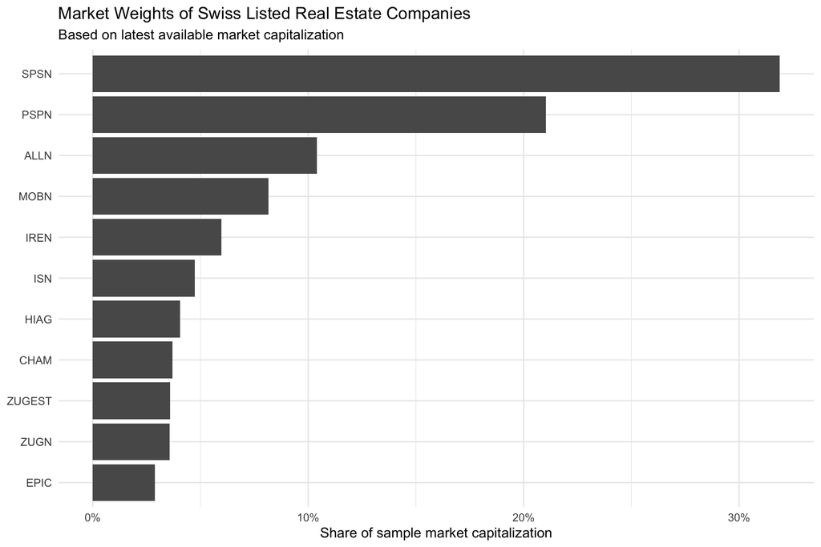

### 6.1.2 A.2 Rolling Correlations with Market Benchmarks

The main analysis reports full-sample return correlations. As an additional robustness check, the following figure shows how the correlation between the constructed REOC portfolios and the Swiss market benchmarks varies over time.

A 36-month rolling window is used.

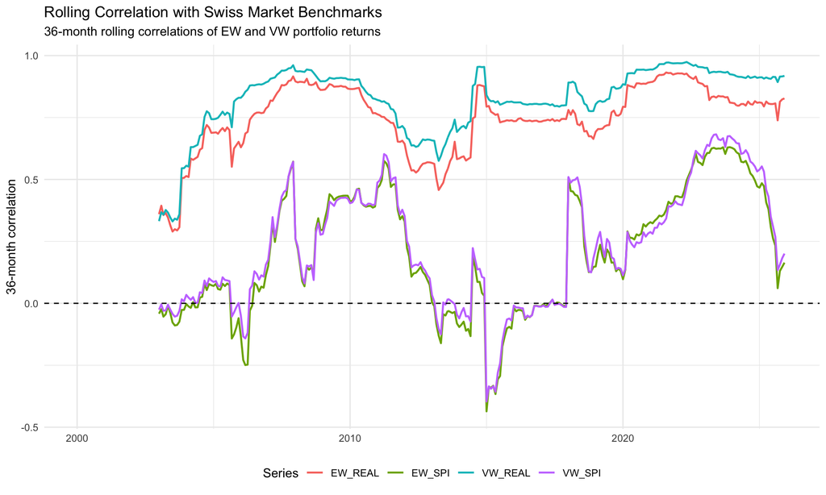

The rolling correlations show that benchmark relationships are not constant through time. The portfolios generally remain more closely related to the listed real-estate benchmark than to the broader equity market, while periods of market stress and structural change produce substantial variation in correlation

## 6.2 B. Additional Analysis for RQ2

This section contains supplementary analyses supporting the investigation of the relationship between REOC market performance and the Swiss macroeconomic environment.

The main report focuses on the most economically relevant results. The additional tables and figures below document data coverage, alternative macroeconomic relationships, volatility, and more detailed regression results.

### 6.2.1 B.1 Monthly Macroeconomic Data Coverage

The monthly macroeconomic dataset is structured as a firm-month panel. Because macroeconomic variables are common to all firms observed in a given month, the data are reduced to one observation per month before evaluating macroeconomic coverage.

Availability of selected monthly macroeconomic variables

| Macroeconomic variable | Missing observations | Available observations |
| --- | --- | --- |
| 3M CHF LIBOR | 25.9% | 74.1% |
| SNB policy rate | 73.7% | 26.3% |
| 10Y Confederation yield | 2.8% | 97.2% |
| Headline inflation | 0.0% | 100.0% |
| Core inflation | 0.0% | 100.0% |
| Seasonally adjusted unemployment | 0.0% | 100.0% |
| Apartment transaction-price index | 0.9% | 99.1% |
| House transaction-price index | 0.9% | 99.1% |
| GDP | 66.8% | 33.2% |

### 6.2.2 B.2 Construction of the Continuous Short-Term Interest Rate

The sample spans a change in the Swiss monetary-policy framework. The 3-month CHF LIBOR provides the short-term interest-rate indicator during the earlier part of the sample, while the SNB policy rate becomes available around the 2019 framework transition.

The following table documents the splice around that transition.

Short-term interest-rate splice around the 2019 monetary-policy framework transition

| Month | 3M CHF LIBOR | SNB policy rate | Constructed short rate |
| --- | --- | --- | --- |
| 2019-01-01 | -0.704 | NA | -0.704 |
| 2019-02-01 | -0.713 | NA | -0.713 |
| 2019-03-01 | -0.707 | NA | -0.707 |
| 2019-04-01 | -0.715 | NA | -0.715 |
| 2019-05-01 | -0.713 | NA | -0.713 |
| 2019-06-01 | -0.711 | -0.75 | -0.711 |
| 2019-07-01 | NA | -0.75 | -0.750 |
| 2019-08-01 | NA | -0.75 | -0.750 |
| 2019-09-01 | NA | -0.75 | -0.750 |
| 2019-10-01 | NA | -0.75 | -0.750 |
| 2019-11-01 | NA | -0.75 | -0.750 |
| 2019-12-01 | NA | -0.75 | -0.750 |

The constructed series uses the available LIBOR observation during the earlier period and the SNB policy rate thereafter. This creates a continuous indicator suitable for the long historical analysis while acknowledging that the underlying monetary-policy reference changed over time.

### 6.2.3 B.3 Full RQ2 Multivariable Regression Results

The main chapter presents a compact regression specification using changes in short- and long-term interest rates, inflation and changes in unemployment.

As an additional robustness analysis, the earlier exploratory specification also includes monthly growth in apartment transaction prices.

Extended portfolio-level regression results for RQ2

| Portfolio | Variable | Estimate | Std. error | t-statistic | p-value |
| --- | --- | --- | --- | --- | --- |
| Equal Weighted | Intercept | 0.0086 | 0.0023 | 3.6673 | 0.0003 |
| Equal Weighted | Change in short-term rate | -0.0212 | 0.0129 | -1.6480 | 0.1004 |
| Equal Weighted | Change in 10-year yield | -0.0510 | 0.0130 | -3.9094 | 0.0001 |
| Equal Weighted | Inflation | -0.0034 | 0.0017 | -2.0552 | 0.0407 |
| Equal Weighted | Change in unemployment | -0.0997 | 0.0245 | -4.0694 | 0.0001 |
| Equal Weighted | Apartment-price growth | 0.3054 | 0.3984 | 0.7664 | 0.4440 |
| Value Weighted | Intercept | 0.0083 | 0.0027 | 3.0698 | 0.0023 |
| Value Weighted | Change in short-term rate | -0.0274 | 0.0148 | -1.8458 | 0.0659 |
| Value Weighted | Change in 10-year yield | -0.0635 | 0.0150 | -4.2246 | 0.0000 |
| Value Weighted | Inflation | -0.0031 | 0.0019 | -1.6191 | 0.1065 |
| Value Weighted | Change in unemployment | -0.1130 | 0.0282 | -4.0075 | 0.0001 |
| Value Weighted | Apartment-price growth | 0.3235 | 0.4588 | 0.7052 | 0.4812 |

The extended specification should be interpreted as a robustness and exploratory exercise rather than as a causal model. The inclusion of several contemporaneous macroeconomic variables may introduce correlation among explanatory variables, and the estimated coefficients should therefore be interpreted cautiously.

### 6.2.4 B.4 Inflation and REOC Returns

Inflation is examined separately as an additional macroeconomic indicator. The original exploratory analysis found relatively weak full-sample correlations between inflation and both aggregate REOC portfolios.

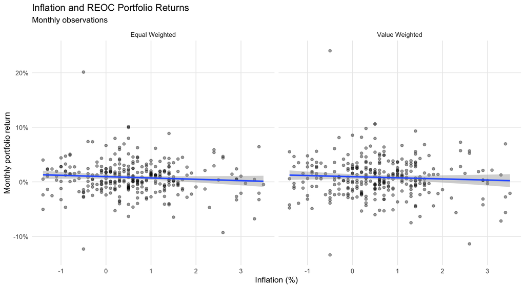

The scatterplots show substantial dispersion around the fitted relationships. Inflation alone therefore explains relatively little of the month-to-month variation in REOC returns.

### 6.2.5 B.5 Labour-Market Conditions and REOC Returns

Changes in seasonally adjusted unemployment provide an additional measure of changes in the economic environment.

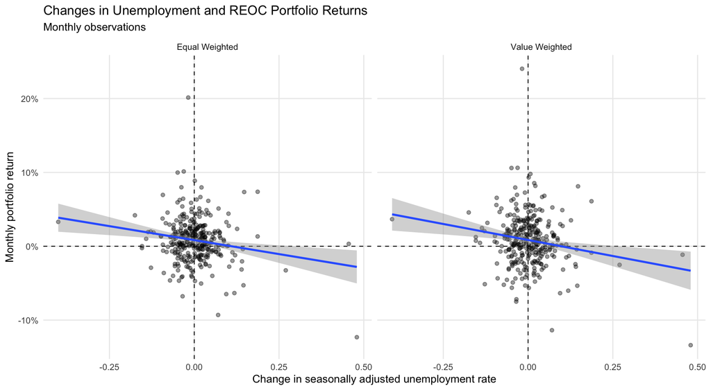

As with inflation, the large dispersion of monthly observations indicates that changes in unemployment are not a dominant standalone explanation of REOC return variation.

### 6.2.6 B.6 Property-Market Momentum and REOC Returns

Because listed REOCs hold direct real-estate assets, an additional exploratory analysis compares listed market returns with changes in Swiss residential transaction-price indices.

The apartment and house price indices are converted into month-to-month growth rates.

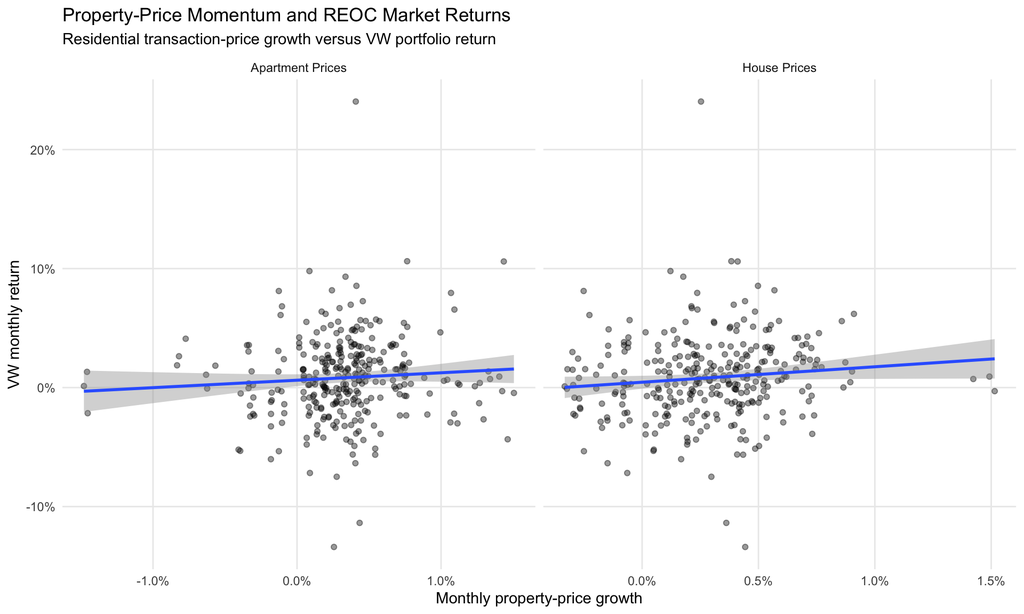

These comparisons are exploratory. Direct property markets and listed securities operate at different frequencies and may incorporate information at different speeds, so a weak contemporaneous monthly relationship does not imply that underlying property-market conditions are irrelevant to REOC values.

### 6.2.7 B.7 Rolling REOC Portfolio Volatility

The main report focuses on return levels and macroeconomic associations. As an additional market-risk measure, the following figure presents rolling realised volatility.

A 12-month rolling standard deviation of monthly returns is used.

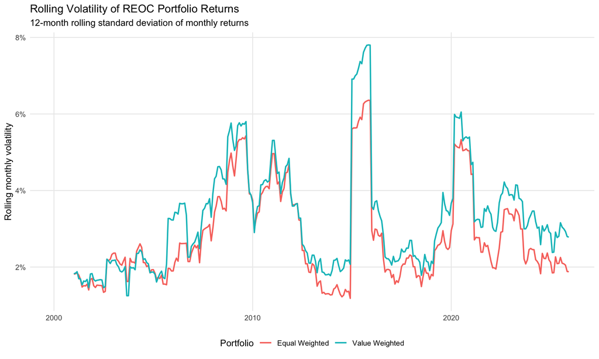

The rolling measure shows that REOC return volatility varies considerably over time. Periods of heightened market uncertainty therefore affect not only realised returns but also the dispersion of monthly performance.

### 6.2.8 B.8 Full Firm-Level RQ2 Sensitivity Estimates

Section 3.1.4 visualises firm-specific sensitivity to changes in long-term interest rates. The complete regression estimates are reported below.

Firm-level RQ2 regression estimates

| Ticker | Variable | Estimate | Std. error | t-statistic | p-value |
| --- | --- | --- | --- | --- | --- |
| HIAG | Change in 10-year yield | -0.1152 | 0.0281 | -4.1059 | 0.0001 |
| ZUGN | Change in 10-year yield | -0.1047 | 0.0220 | -4.7685 | 0.0000 |
| PSPN | Change in 10-year yield | -0.0926 | 0.0193 | -4.7974 | 0.0000 |
| EPIC | Change in 10-year yield | -0.0872 | 0.0234 | -3.7187 | 0.0007 |
| IREN | Change in 10-year yield | -0.0827 | 0.0223 | -3.7077 | 0.0003 |
| MOBN | Change in 10-year yield | -0.0825 | 0.0195 | -4.2337 | 0.0000 |
| SPSN | Change in 10-year yield | -0.0721 | 0.0186 | -3.8827 | 0.0001 |
| ZUGEST | Change in 10-year yield | -0.0658 | 0.0249 | -2.6442 | 0.0091 |
| ALLN | Change in 10-year yield | -0.0591 | 0.0161 | -3.6705 | 0.0003 |
| ISN | Change in 10-year yield | -0.0453 | 0.0163 | -2.7799 | 0.0058 |
| CHAM | Change in 10-year yield | -0.0091 | 0.0336 | -0.2693 | 0.7886 |
| EPIC | Inflation | -0.0049 | 0.0038 | -1.2956 | 0.2036 |
| MOBN | Inflation | -0.0038 | 0.0024 | -1.5937 | 0.1123 |
| IREN | Inflation | -0.0027 | 0.0029 | -0.9370 | 0.3509 |
| ALLN | Inflation | -0.0026 | 0.0021 | -1.2448 | 0.2142 |
| HIAG | Inflation | -0.0021 | 0.0033 | -0.6454 | 0.5198 |
| SPSN | Inflation | -0.0019 | 0.0024 | -0.7710 | 0.4413 |
| ZUGEST | Inflation | -0.0016 | 0.0029 | -0.5309 | 0.5963 |
| ISN | Inflation | -0.0013 | 0.0021 | -0.6091 | 0.5429 |
| ZUGN | Inflation | -0.0009 | 0.0026 | -0.3404 | 0.7340 |
| PSPN | Inflation | -0.0002 | 0.0025 | -0.0602 | 0.9520 |
| CHAM | Inflation | 0.0011 | 0.0044 | 0.2515 | 0.8023 |

The detailed estimates reinforce the main finding that REOCs differ in the magnitude of their exposure to macroeconomic conditions. These coefficients remain descriptive associations rather than causal estimates.

## 6.3 C. Additional Analysis for RQ3

This section reports additional descriptive and statistical results concerning the relationship between firm fundamentals and the macroeconomic environment.

The main report focuses on the long-term yield–leverage relationship and the contrast between pooled and within-firm evidence. The following material documents the broader exploratory analysis supporting that choice.

### 6.3.1 C.1 Annual Firm-Level Data Coverage

The annual accounting panel is unbalanced because the number of historical observations differs across firms.

Coverage of the annual firm-level sample

| Ticker | Firm-year observations | First year | Last year |
| --- | --- | --- | --- |
| ALLN | 25 | 2001 | 2025 |
| ISN | 25 | 2001 | 2025 |
| PSPN | 25 | 2001 | 2025 |
| SPSN | 25 | 2001 | 2025 |
| MOBN | 22 | 2004 | 2025 |
| ZUGEST | 15 | 2011 | 2025 |
| ZUGN | 15 | 2011 | 2025 |
| HIAG | 14 | 2012 | 2025 |
| IREN | 13 | 2013 | 2025 |
| EPIC | 7 | 2019 | 2025 |
| CHAM | 6 | 2020 | 2025 |

Companies entering the dataset later have shorter historical series. Firm-specific correlations and regressions based on these firms should therefore be interpreted more cautiously than estimates for REOCs with long histories.

### 6.3.2 C.2 Missingness in Core Annual Firm Variables

Missingness of selected RQ3 variables

| Variable | Missing observations | Available observations |
| --- | --- | --- |
| debt_to_assets | 0.0% | 100.0% |
| net_debt_ebitda | 4.2% | 95.8% |
| fa_total_assets | 0.0% | 100.0% |
| net_income | 4.7% | 95.3% |
| dividend_per_share | 9.4% | 90.6% |
| confederation_10y | 0.0% | 100.0% |
| jobless_rate_sa | 0.0% | 100.0% |
| gdp | 0.0% | 100.0% |

### 6.3.3 C.3 Descriptive Statistics for Annual Firm Fundamentals

Descriptive statistics for selected annual firm fundamentals

| variable | N | Mean | Median | SD | Min | Max |
| --- | --- | --- | --- | --- | --- | --- |
| Debt / Assets | 192 | 39.21 | 40.20 | 10.19 | 0.00 | 71.53 |
| Net Debt / EBITDA | 184 | 9.81 | 8.12 | 11.88 | 1.71 | 151.42 |
| Total Assets | 192 | 3118.83 | 1814.86 | 3165.40 | 355.02 | 15780.76 |
| Net Income | 183 | 212.77 | 105.24 | 237.45 | 18.11 | 1131.87 |
| Dividend per Share | 174 | 8.95 | 3.18 | 26.12 | 0.00 | 196.12 |
| ROA | 183 | 6.74 | 5.38 | 4.33 | 1.07 | 26.70 |
| Asset Growth | 181 | 10.08 | 7.11 | 15.83 | -11.83 | 123.94 |

### 6.3.4 C.4 Full Macro × Firm Fundamentals Correlation Matrix

The following matrix extends the main RQ3 discussion by comparing five macroeconomic variables with four firm-level financial characteristics.

Pearson correlations between macroeconomic indicators and firm fundamentals

| Macroeconomic variable | Debt / Assets | Net Debt / EBITDA | ROA | Asset Growth |
| --- | --- | --- | --- | --- |
| Short-term rate | 0.15 | 0.21 | -0.13 | 0.01 |
| 10Y government yield | 0.32 | 0.12 | -0.05 | 0.14 |
| GDP growth | -0.04 | -0.07 | -0.04 | 0.05 |
| Inflation | -0.02 | 0.22 | -0.14 | 0.04 |
| Unemployment | 0.14 | -0.18 | 0.11 | 0.06 |

The correlation matrix confirms that most macro-fundamental relationships are relatively weak. The most notable pooled relationship is between the 10-year government yield and debt-to-assets.

### 6.3.5 C.5 Macro × Firm Fundamentals Correlation Heatmap

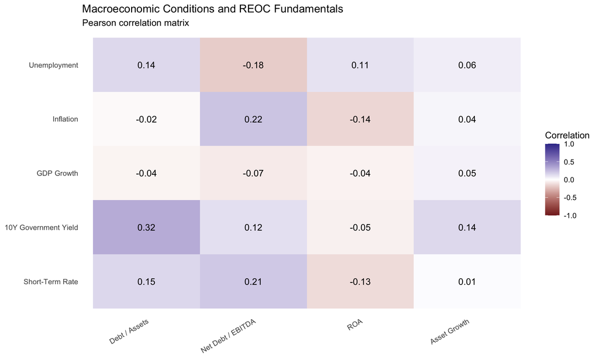

Positive values indicate that the variables tend to move in the same direction, while negative values indicate opposite co-movement. Values close to zero indicate little linear association.

### 6.3.6 C.6 Full Firm-Specific Yield–Leverage Correlation Table

The main report visualises the heterogeneous relationship between the 10-year Confederation yield and leverage. The complete numerical results are reported below.

Firm-specific correlations between the 10-year Confederation yield and debt-to-assets

| Ticker | Observations | Correlation |
| --- | --- | --- |
| SPSN | 25 | 0.786 |
| PSPN | 25 | 0.739 |
| ISN | 25 | 0.687 |
| CHAM | 6 | -0.001 |
| ALLN | 25 | -0.024 |
| ZUGEST | 15 | -0.256 |
| ZUGN | 15 | -0.256 |
| HIAG | 14 | -0.336 |
| MOBN | 22 | -0.495 |
| IREN | 13 | -0.573 |
| EPIC | 7 | -0.910 |

The full table demonstrates that the pooled positive correlation masks considerable heterogeneity across firms. Firms with shorter histories should be interpreted cautiously because their correlations are based on substantially fewer annual observations.

### 6.3.7 C.7 Short-Term Interest Rates and Leverage

The main report focuses on the long-term government yield because it produced the strongest pooled relationship with debt-to-assets. For completeness, the short-term interest-rate relationship is also reported.

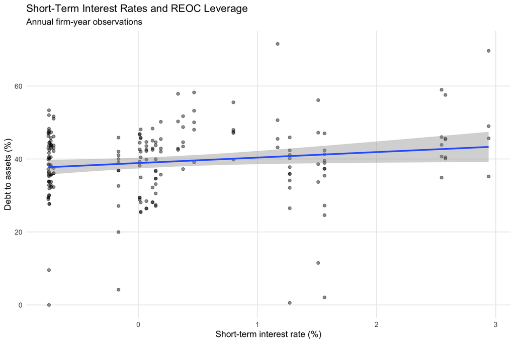

Short-term interest rates and leverage: levels and annual changes

| Relationship | Correlation |
| --- | --- |
| Rate level vs. leverage level | 0.150 |
| Rate change vs. leverage change | -0.027 |

The short-rate results are weaker than the long-term yield relationship and therefore remain supplementary to the main RQ3 analysis.

### 6.3.8 C.8 Firm Size and Leverage

Firm size may itself be associated with capital structure. The following analysis compares total assets with debt-to-assets.

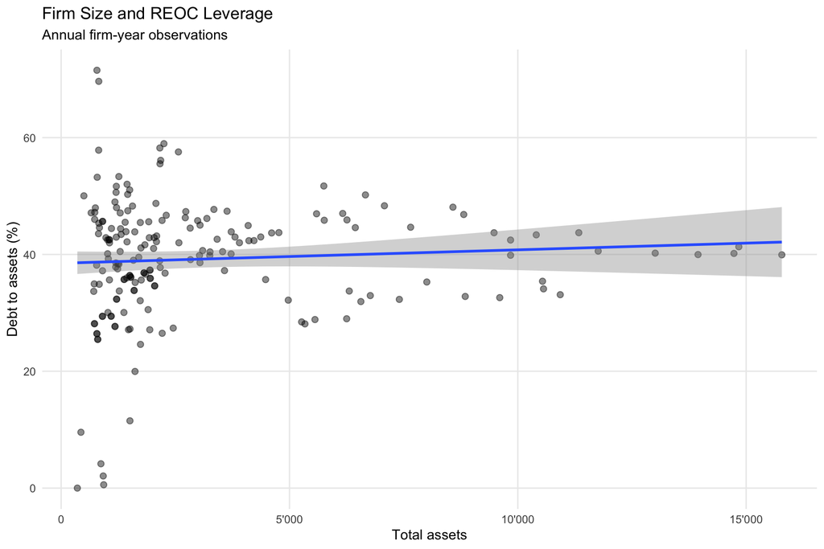

The pooled relationship between total assets and leverage is weak. Firm size alone therefore does not appear to explain much of the cross-sectional variation in debt-to-assets within the sample.